# Simulation of Exponential Distribution Approaching Normal Distribution Using R

Tyler Peterson

10/25/2016

# Part One: Simulation Exercise

## Simulate The Exponential Distribution

For our simulation we will show the progression of the sample mean as we generate 1000 simulations over 40 exponentials. Following we simulate the distributions of means from 1 to 40 exponentials.

```r
# Show convergence progression to the normal distribution over 40 simulations
  overallMean <- c()
  overallSD <- c()
  overallVar <- c()
  for(i in 1:n){
    expData <- rexp(n = i*numSims, rate = lambda)
    expDataMatrix <- matrix(expData, nrow = numSims, ncol = i)
    expDataMeanArray <- apply(expDataMatrix, 1, mean)
    overallMean <- c(overallMean, mean(expDataMeanArray))
    overallSD <- c(overallSD, sd(overallMean))
    overallVar <- c(overallVar, var(overallMean))
  }
```

We plot the simulation here along with the overall mean value to illustrate the ultimate convergence of the exponential distribution to 5.

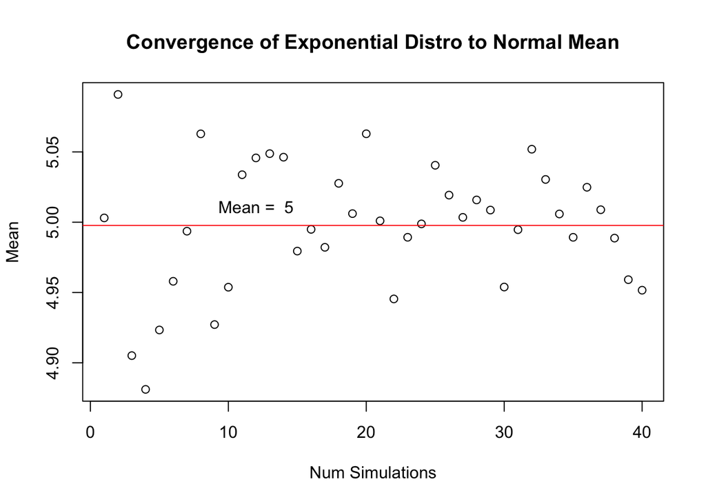

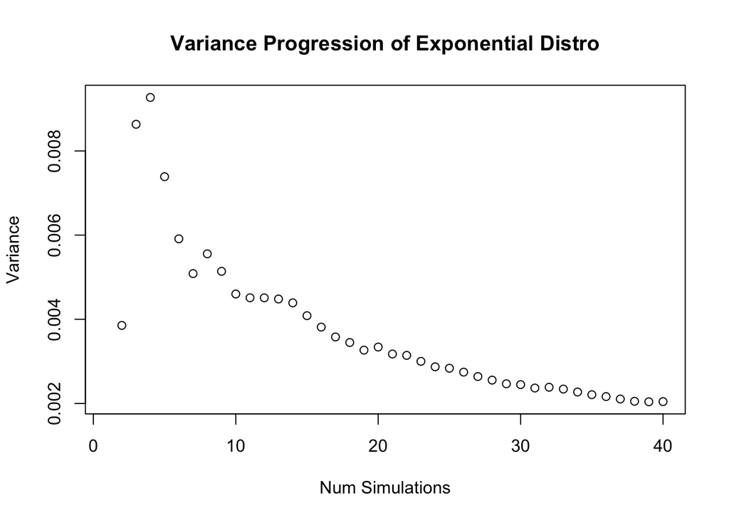

```r
# Show distribution of means over final simulation:
  finalExpData <- rexp(n = n*numSims, rate = lambda)
  finalExpDataMatrix <- matrix(finalExpData, nrow = numSims, ncol = n)
  finalExpMeanArray <- apply(finalExpDataMatrix, 1, mean)
  finalExpMean <- mean(finalExpMeanArray)
  finalExpSD <- sd(finalExpMeanArray)
  finalExpVar <- var(finalExpMeanArray)
  standError <- finalExpSD/sqrt(n)
  upperCI <- finalExpMean + 1.96*standError
  lowerCI <- finalExpMean - 1.96*standError
```

As we model the 40th exponential, we can see that the mean closely approximates the true mean of 5.0 with a value of 4.9858178.

## Simulate The Normal Distribution

```r
# Normal distribution
  normDist <- rnorm(n = numSims, mean = 1/lambda, sd = 1/lambda)
  normDistMean <- mean(normDist)
  normDistSD <- sd(normDist)
  normDistVar <- var(normDist)
```

Notice that the mean of this distribution is 4.8175763. This mean is very close to the mean simulated in the exponential simulation. We plot these distributions side by side to show that they both appear to be distributed normally around their respective means.

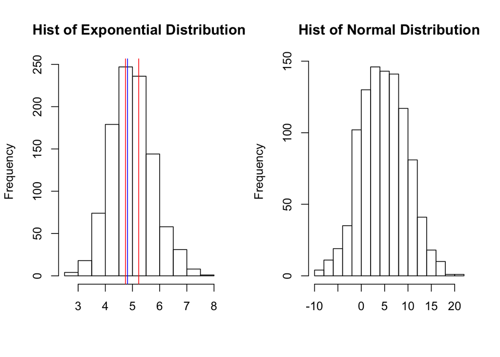

Notice that the distributions are very similar in shape. Also notice that the red and blue lines in the Exponential Distribution. The red lines indicate a 95% upper and lower confidence interval. The blue line indicates the true mean of the normal distribution. Notice that the normal distribution’s mean lies within the 95% confidence interval of the exponential mean’s distribution. Our conclusion is therefore that the means of the exponential distribution begin to resemble that of the normal distribution as the number of simulations grows.

# Part Two: Basic Inferential Data Analysis

## Overview

In this project, we analyze the length of odontoblasts (cells responsible for tooth growth) in 60 guinea pigs. Each animal received one of three dose levels of vitamin C (0.5, 1, and 2 mg/day) by one of two delivery methods - orange juice (coded as OJ) or ascorbic acid (a form of vitamin C and coded as VC).

## Exploring the data:

```r
# Exploring the data
  str(df)
```

```
## 'data.frame':    60 obs. of  3 variables:
##  $ len : num  4.2 11.5 7.3 5.8 6.4 10 11.2 11.2 5.2 7 ...
##  $ supp: Factor w/ 2 levels "OJ","VC": 2 2 2 2 2 2 2 2 2 2 ...
##  $ dose: num  0.5 0.5 0.5 0.5 0.5 0.5 0.5 0.5 0.5 0.5 ...
```

```r
  #head(df)
  #df
```

From examining the dataset, we see that the structure of the ToothGrowth dataframe contains 2 levels for the supplementation column (supp), which is a factor variable, but an unknown number of levels for the dose and length (len) columns. In our analyses, we expect the len variable to be the dependent variable, so we are less concerned with the number of levels it contains, but need to know the number of levels the dose variable has. We aggregate the length based on dose size and and see the number of unique tooth lengths per dose size For consistency, we aggregate the length based on supplement type to see the number of unique tooth lengths supplement types. From this we see that both dose size and supplement size are discrete variables and will be treated as such in the analysis.

```r
  aggregate(len ~ dose, df, function(x) length(unique(x)))
```

```
##   dose len
## 1  0.5  17
## 2  1.0  17
## 3  2.0  17
```

```r
  aggregate(len ~ supp, df, function(x) length(unique(x)))
```

```
##   supp len
## 1   OJ  25
## 2   VC  27
```

We create several plots to attempt to visually determine a pattern and see what to expect when performing the analysis. We first plot tooth length against supplement type with coloration per dose size. This plot is not very helpful in establishing a distinct relationship between supplement type and tooth length. We will not be using this plot in our analysis.

In our second plot, we plot tooth length against dose size with coloration per supplement type. In this plot, it appears that there is a correlation between tooth length and dose size; larger dose sizes lead to longer tooth lengths.

The third plot is a histogram of the tooth lengths. We include this plot to simply illustrate that there does not appear to be any outliers in the tooth lengths and we can include all tooth lengths in our analysis.

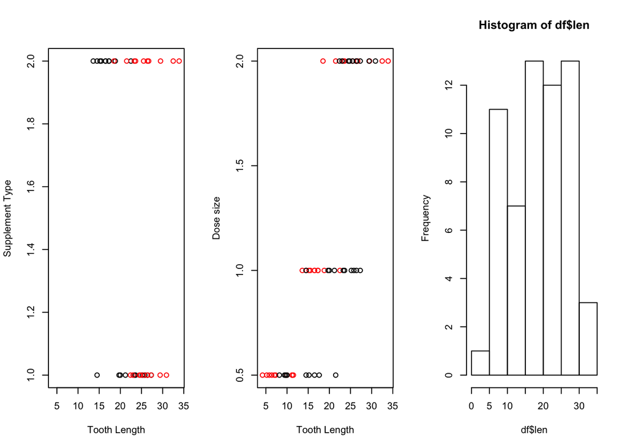

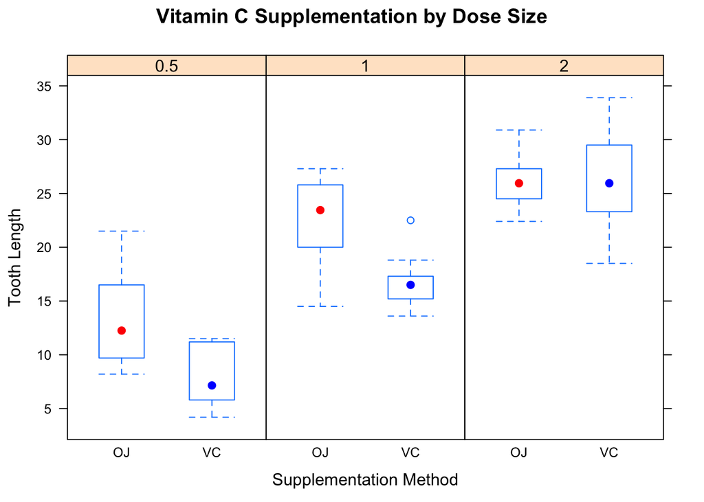

## Analyzing the data

### First test is checking to see if the dose size affects the tooth length

- H0 = Tooth length is not affected by dose size
- Ha = Tooth length is affected by dose size

```r
  # Separate dose size into distinct subsets:
  doseSub1 <- subset(df, df$dose %in% c(0.5, 1.0))
  doseSub2 <- subset(df, df$dose %in% c(0.5, 2.0))
  doseSub3 <- subset(df, df$dose %in% c(1.0, 2.0))

  # Perform single tailed T Tests on the subsetted data
  doseTTest1 <- t.test(len ~ dose, data = doseSub1)
  doseTTest2 <- t.test(len ~ dose, data = doseSub2)
  doseTTest3 <- t.test(len ~ dose, data = doseSub3)

  doseTTest1
```

```
##
##  Welch Two Sample t-test
##
## data:  len by dose
## t = -6.4766, df = 37.986, p-value = 1.268e-07
## alternative hypothesis: true difference in means is not equal to 0
## 95 percent confidence interval:
##  -11.983781  -6.276219
## sample estimates:
## mean in group 0.5   mean in group 1
##            10.605            19.735
```

```r
  doseTTest2
```

```
##
##  Welch Two Sample t-test
##
## data:  len by dose
## t = -11.799, df = 36.883, p-value = 4.398e-14
## alternative hypothesis: true difference in means is not equal to 0
## 95 percent confidence interval:
##  -18.15617 -12.83383
## sample estimates:
## mean in group 0.5   mean in group 2
##            10.605            26.100
```

```r
  doseTTest3
```

```
##
##  Welch Two Sample t-test
##
## data:  len by dose
## t = -4.9005, df = 37.101, p-value = 1.906e-05
## alternative hypothesis: true difference in means is not equal to 0
## 95 percent confidence interval:
##  -8.996481 -3.733519
## sample estimates:
## mean in group 1 mean in group 2
##          19.735          26.100
```

### Second test is checking to see if the supplement type affects tooth length

- H0 = Tooth length is not affected by supplement type
- Ha = Tooth length is affected by supplement type

```r
  # Since there only exists 2 types of supplementation, we will not subset the dataset
  suppTTest <- t.test(len~supp, data = df)
  suppTTest
```

```
##
##  Welch Two Sample t-test
##
## data:  len by supp
## t = 1.9153, df = 55.309, p-value = 0.06063
## alternative hypothesis: true difference in means is not equal to 0
## 95 percent confidence interval:
##  -0.1710156  7.5710156
## sample estimates:
## mean in group OJ mean in group VC
##         20.66333         16.96333
```